# Does The GDP and Population of a Country Affect the Number of Medals They Win and How Does It Affect the Sports They Excel In?

In this part of the report the wealth and population of a country will be explored in order to build a macro-level insight on how an athlete’s environment as indicated by the economic and demographic environment they live in affect their performance in the Olympics.

# Datasets

The olympics dataset was then merged with datasets containing the GDP and population of each country. The datasources were from:

Population:

https://knoema.com/UNWPP2019/world-population-prospects-2019

GDP:

https://data.worldbank.org/indicator/NY.GDP.MKTP.CD

Both datasets had missing data for several past decades and for some of the countries that did not participate in the Olympics. However, for the countries that did participate and still had missing data- these were filled by extrapoilating the average of the years the preceded and followed.

# EDA

As a first step to the EDA, for the year 2000 until present, bar charts of the total number of medals won by each country and gross domestic product per capita (GDPpC) were plotted for preliminary comparison.

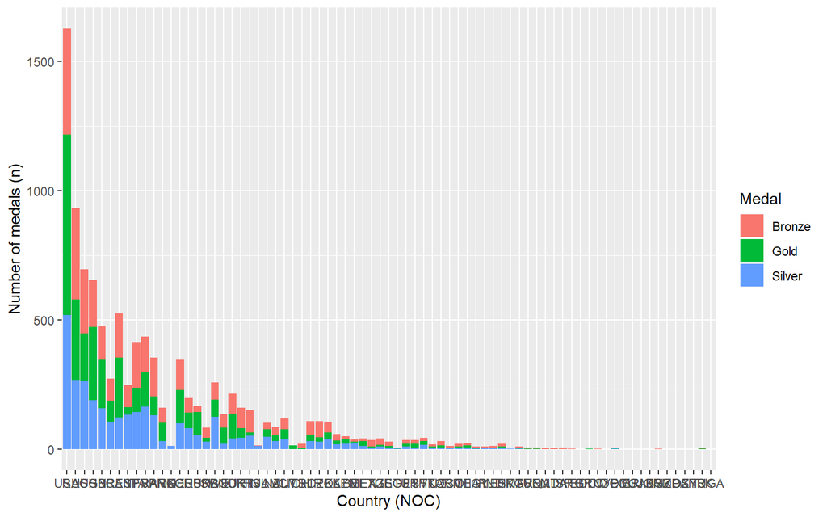

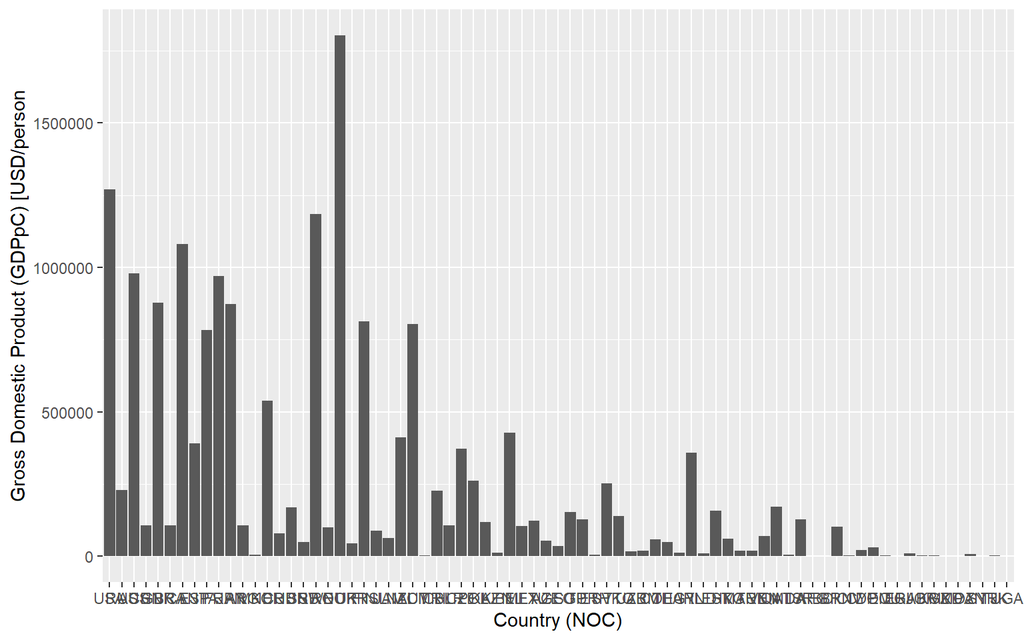

Looking at a few randomly picked countries the following is obsereved:

| Country | n | GDPpC rank | Population |
| --- | --- | --- | --- |
| Luxembourg | 0 | 1st | 169th |
| Norway | 216 | 3rd | 119th |
| USA | 1626 | 7th | 3rd |
| Russia | 933 | 61st | 9th |
| Jordan | 1 | 109th | 88th |
| Ukraine | 161 | 119th | 35th |

### Relationship between Medals Won and Competing Country’s GDP per Capita (year 2000-present)

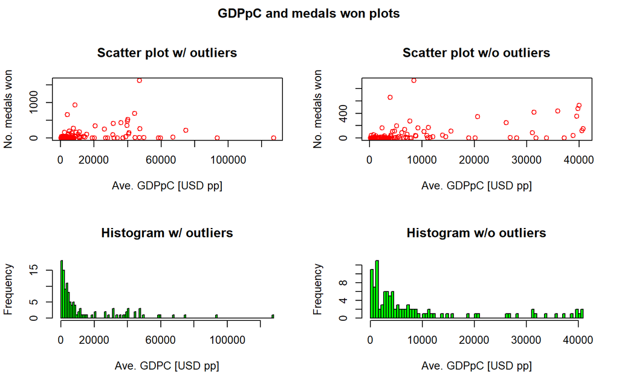

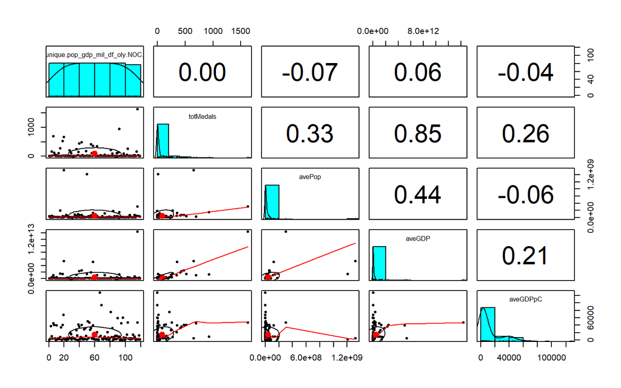

The scatter plots show a positive up trend. Also the pairplots show a stronger correlation between average GPD and number of medals won when compared to population and GDPpC. The table below summarizes the numbers

|  | Ave population | Ave GDPpC | Ave GDP |
| --- | --- | --- | --- |
| Medals won | 0.33 | 0.26 | 0.85 |

### Relationship Between Sports and Competing Country’s GDP per Capita (year 2000-present)

Another interesting relationship to explore is the number of medals won in a particular sport and the GDPpC of the competing countries.

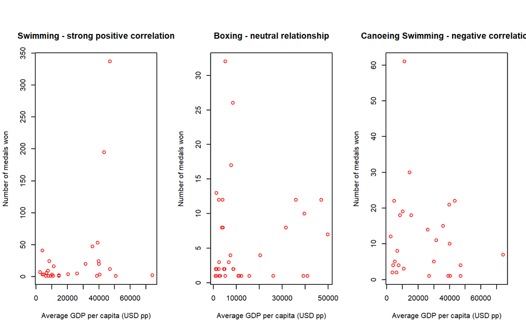

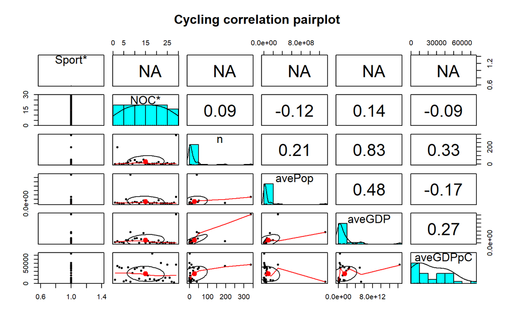

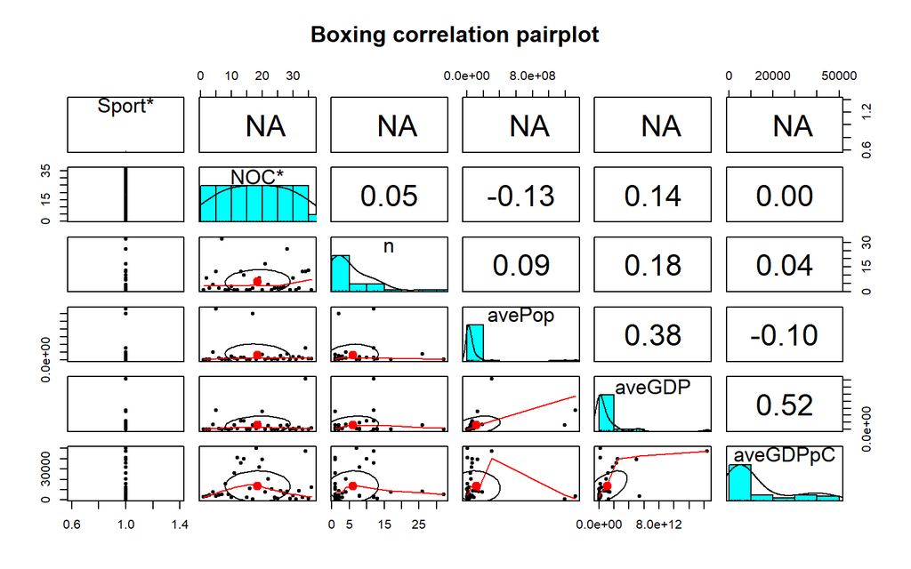

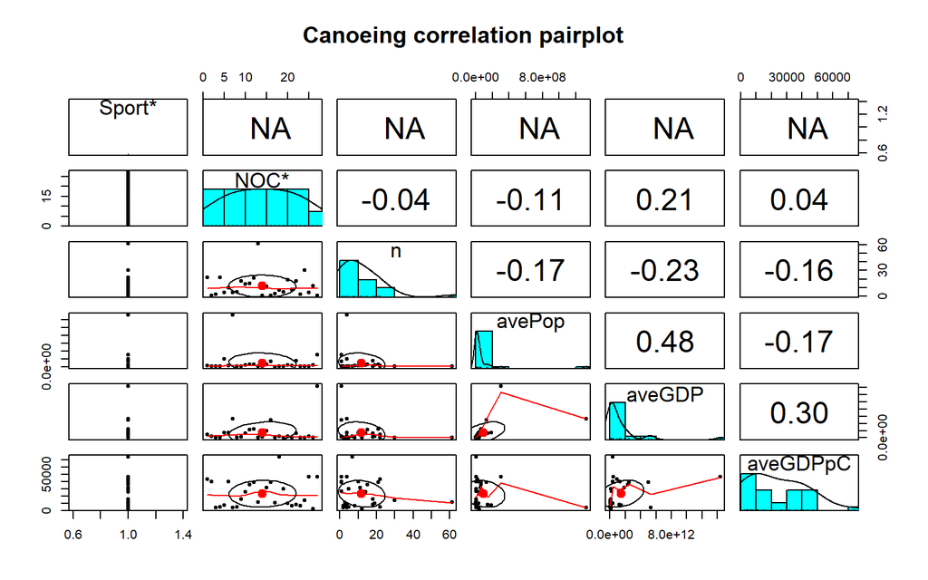

The results showed that each sport indeed has a different relationship with a sport when compared with the relavent countries GDPpC. The table below summarize the claculated correlation factor for three sports with positive, near zero and negative correlation.

[output not shown]

# Additional Information

The results of this investigation could be further improved if the data on the percentage of the GDP that gets allocated to the Olympic Committee of each of these countries. Also, the world happiness report, Corruption Perceptions Index (rank), life expectancy and literacy could all be included to develop a more well rounded look into the various factors that my affect an athlete’s performance due to the environment they lived in.

2020-03-22